# **Part 2 - The Investigation of the Distribution of Loans from Prosper Loan Data**

### *by Abdullah Akintobi*

## Investigation Overview

In this investigation, I wanted is look at the distribution of Loans of Prosper to help them understand how their loans are distribuated from the year 2005 to 2014. The main focus was on loan information, such as borrower state, borrower stated income, loan original amount and monthly loan payment.

## Dataset Overview

This document explores a dataset containing 113,937 loans with 81 variables on each loan, including loan amount, borrower rate (or interest rate), current loan status, borrower income, and many others. I focused my exploration on 13 of them. The variables I involved in my explanatory presentation are "Term", "LoanStatus", "BorrowerState", "StatedMonthlyIncome", "LoanOriginalAmount", "LoanOriginationDate", "LoanOriginationQuarter", "MonthlyLoanPayment". Eight Hundred Seventy-one duplicated data points were removed from the dataset.

### **Distribution of Loan Status**

The proportion of each loan status are as follows:

- The proportion of Current is 49.29%
- The proportion of Completed is 33.663%
- The proportion of Chargedoff is 10.606%
- The proportion of Defaulted is 4.438%
- The proportion of Past Due is 1.819%
- The proportion of InProgress is 0.18%
- The proportion of Cancelled is 0.004%

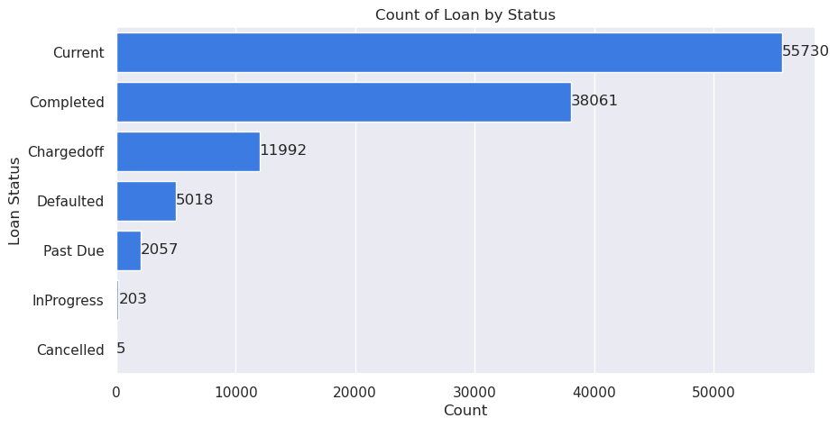

### **Distribution of loan by state**

Most of the borrowers amounting to 14594 loans are from CA (California) and occupies approximately, 12.91% of the loans. Also, there are 5515 loans that the borrower doesn't specify his/her state.

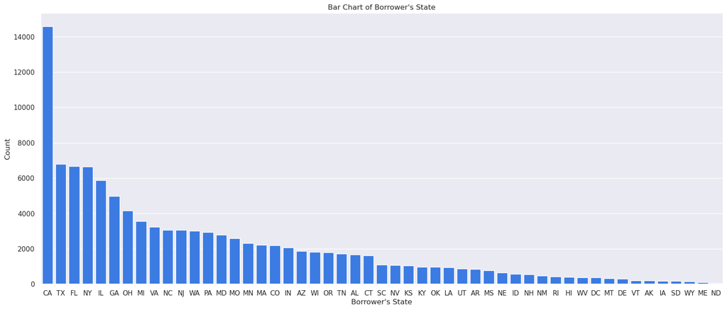

### **Distribution of the borrower Stated Monthly Income**

Most of the borrowers stated monthly income are from 3k to 6k. There are also a lots of outliers in the data set with a wide range between the outliers. Also, when the dataset was investigated further, it was observered that most of the borrowers monthly income are false.

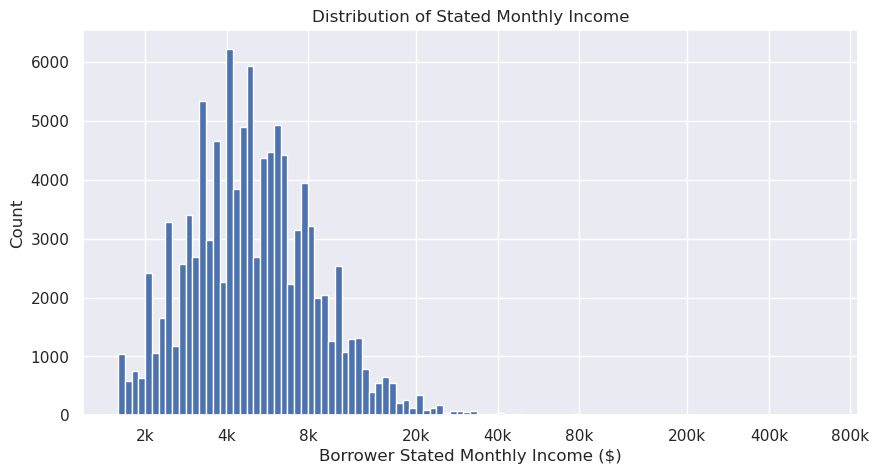

### **Distribution of the Loan Original Amount**

There are three peaks at 4K, 10K, and 15K Loan Original Amount which shows that most demanded loan amount by borrower are `$4000, $15000 and $10000` respectively.

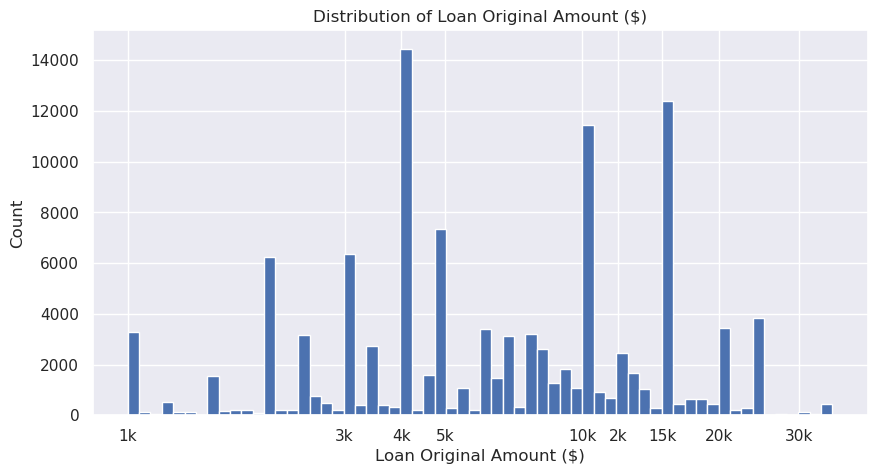

### **The year (in quarters) that has the highest loan demands**

The amount of loans increases rapidly within the year 2013

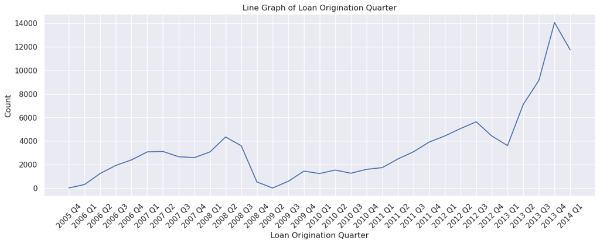

### **How Loan Original Amount changes with time (yearly quarters)**

There is a huge decrease of loans amount between the forth quarter of the year 2008 and the second quarter of the year 2009 which was due to the Financial Crisis in the US during those period. The amount of loans also increases by year from the year 2010 to year 2014.

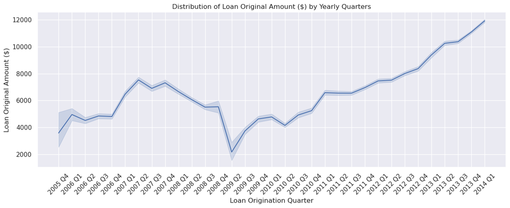

### **Distribution of loans by state**

Most of the borrowers are from `California (CA)` and total amount of loans that went to the state is `$130,687,003` amounting to approximately `13.9%` of the total amount loan `($940,116,915)` given out by the company.

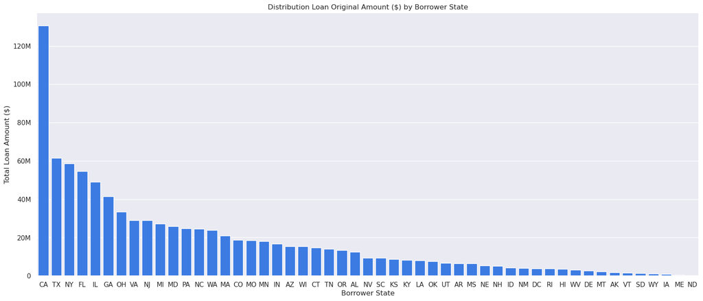

### **The relationship between Loan Original Amount, Loan Origination Year and Term**

The 12 months and 60 months loan terms were introduced in the year 2010 and 12 months loans were later stoped in the year 2013 with increase in 12 months loan terms within the period. It also shows the increasing in demand of loans from the year 2012 for all loan terms.

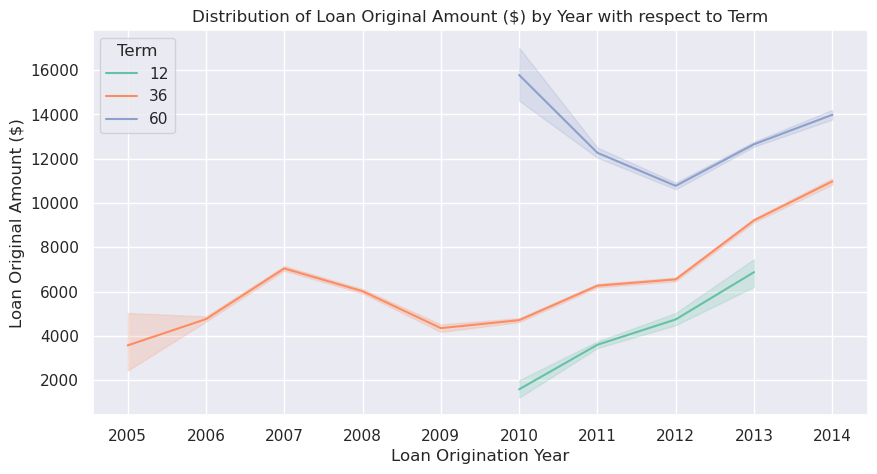

### **Relationship between Loan Original Amount and Monthly Loan Payment with repect to Year**

There is a positive correlation between Loan Original Amount and Monthly Loan Payment and increase in Loan Original Amount and Monthly Loan Payment by Year.

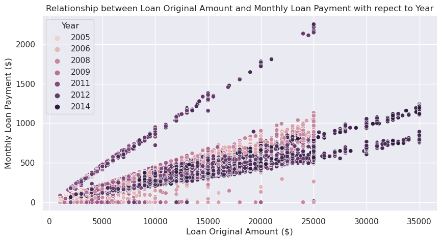

### **Thank You For Your Time And Attention!**